# Tutorial: Using XGBoost for Species-Distribution-Modelling

## 5.2 ) Data preparation

Let’s begin with preparing the data used to train the model. Start with getting a overview of the provided data:

```r
species_occurrences_all <- read.table("data/PakistanLadakh.csv", sep=",", header=TRUE)
species_occurrences_all <- sf::st_as_sf(species_occurrences_all, coords=c("x", "y"), remove=TRUE, crs=sf::st_crs("epsg:4326"))

str(species_occurrences_all)
```

```
## Classes 'sf' and 'data.frame':   5870 obs. of  2 variables:
##  $ species : chr  "Acraea_issoria" "Acraea_issoria" "Acraea_issoria" "Acraea_issoria" ...
##  $ geometry:sfc_POINT of length 5870; first list element:  'XY' num  73.1 34.4
##  - attr(*, "sf_column")= chr "geometry"
##  - attr(*, "agr")= Factor w/ 3 levels "constant","aggregate",..: NA
##   ..- attr(*, "names")= chr "species"
```

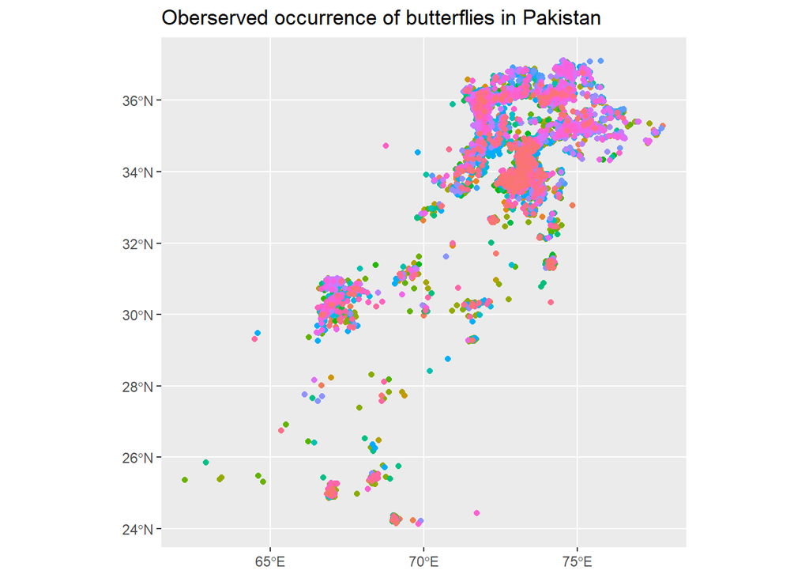

```r
ggplot() +
  geom_sf(data = sf::st_as_sf(species_occurrences_all), mapping=aes(color=species), show.legend = FALSE) +
  ggtitle("Oberserved occurrence of butterflies in Pakistan")
```

Next we need some environmental data to train the model. Therefor we selected the bioclim data, which are widely used in speceis distribution modeling (Source: https://isprs-archives.copernicus.org/articles/XLII-4-W19/449/2019/isprs-archives-XLII-4-W19-449-2019.pdf#:~:text=The%20earliest%20studies%20of%20SDM%20used%20BIOCLIM%20-,requires%20species%20occurrence%20data%20%28latitude%2C%20longitude%2C%20and%20elevation%29.). Bioclim is missing elevation data, we will use those too, since temperature is depend on elevation. The Border of Pakistan is also needed, we will crop our data with that, so the model doesn’t train areas were does not have presence points.

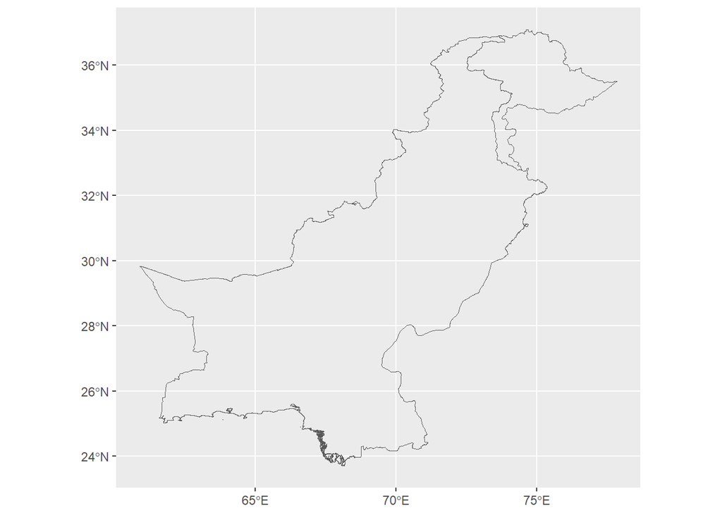

```r
# political border of pakistan
border_pak <- geodata::gadm(country='PAK', level = 0, path='./data')
ggplot() +
  geom_sf(data = sf::st_as_sf(border_pak), fill=NA)
```

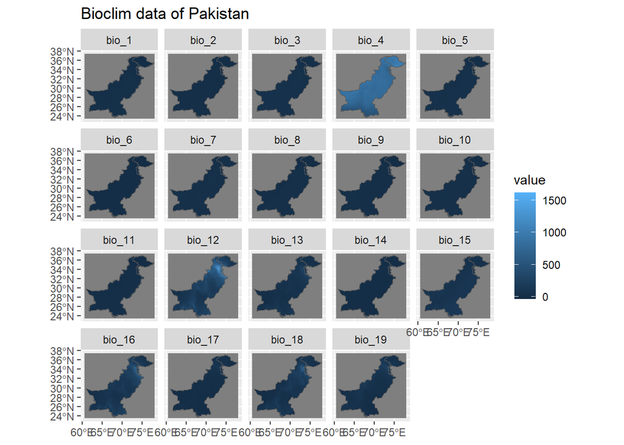

```r
# bioclim data from pakistan
bioclim_pak <- geodata::worldclim_country(country = "PAK", res = 10, var = "bio", path = "data/", version = "2.1")
names(bioclim_pak) <- substr(names(bioclim_pak), 11, 20) # TODO: rename to mare meaningful names or show table of layers in text
bioclim_pak <- terra::mask(bioclim_pak, border_pak)
ggplot() +
  geom_spatraster(data = bioclim_pak) +
  facet_wrap(~lyr) +
  geom_sf(data = sf::st_as_sf(border_pak), fill = NA, show.legend = FALSE) +
  ggtitle("Bioclim data of Pakistan")
```

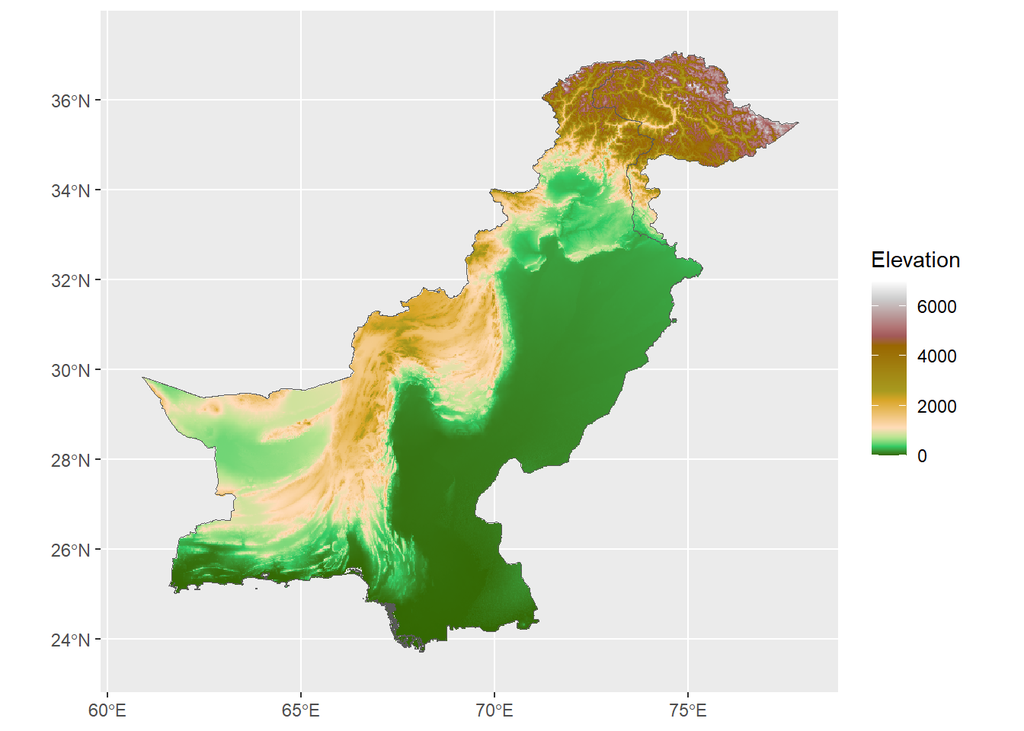

```r
# elevation data form pakistan
elevation_pak <- geodata::elevation_30s(country = 'PAK', path = 'data/')
ggplot() +
  geom_spatraster(data = elevation_pak) +
  geom_sf(data = sf::st_as_sf(border_pak), fill = NA, show.legend = FALSE) +
  scale_fill_hypso_c(name = "Elevation")
```

So lets define our species_occurrences as presence points :

```r
species_presence <- species_occurrences_all
rm(species_occurrences_all)
```

As absence points we will user random Points in Pakistan and combine them with the presence points. The absence points will be extended by a column “species”, which matches the column “species”´in the presence points.

```r
# Generate random points inside pakistan as background points and extend them with a column for species = NA
# TODO: why 1000 points?? give a explanation for the decision
border_pak <- sf::st_as_sf(border_pak)
species_absence <- sf::st_sample(border_pak, size = 1000)

# TODO: add col for occurrence = 1 or occurrence = 0 here, dummycols can then be thrown away
# adding col species = NA to the background points, needed for rbind to join the data
species_absence <- cbind(species_absence, data.frame(species = as.character(NA)))
species_absence <- sf::st_as_sf(species_absence)

# Combine presence and absence (background) points into a single object
modeling_data_ <- rbind(species_presence, species_absence)

# Only points inside Pakistan should be used for modeling, also remove the columns added by the intersection.
modeling_data_ <- sf::st_intersection(modeling_data_, border_pak) %>% select(-COUNTRY, -GID_0)
```

Now we got our presence and absence points as spatial data. Finally we will extract values from our environmental data and add those to our modeling data, so xgboost can use this table to train its model.

```r
# Extract values from bioclim and elevation, join them to our modeling_data
extraction_bioclim_pak <- terra::extract(bioclim_pak, modeling_data_, bind=FALSE, ID=FALSE)
extraction_elevation_pak <- terra::extract(elevation_pak, modeling_data_, bind=FALSE, ID=FALSE)
modeling_data_extracted <- cbind( modeling_data_, extraction_bioclim_pak, extraction_elevation_pak)
```

Clean up of no longer needed variables and check the final modeling data:

```r
# create a final data variable and clean up variables
modeling_data <- modeling_data_extracted

rm(species_occurrences_all); rm(species_presence); rm(species_absence); rm(modeling_data_); rm(extraction_bioclim_pak); rm(extraction_elevation_pak); rm(modeling_data_extracted)
```

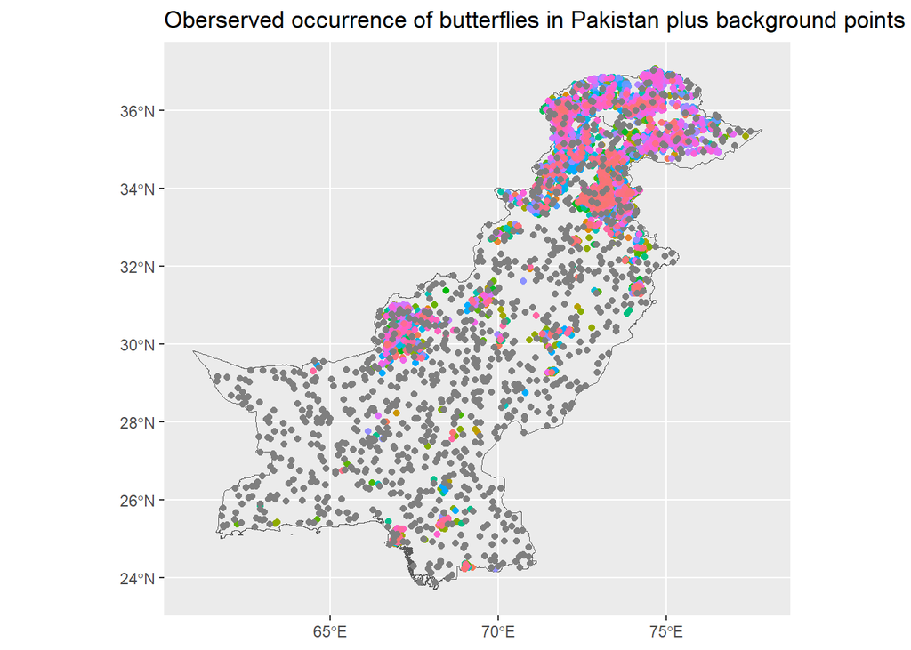

```
## Classes 'sf' and 'data.frame':   6746 obs. of  22 variables:
##  $ species    : chr  "Acraea_issoria" "Acraea_issoria" "Acraea_issoria" "Acraea_violae" ...
##  $ bio_1      : num  17.7 12.2 15.4 24.2 13.9 ...
##  $ bio_2      : num  12.1 10.4 11.3 14.5 11.6 ...
##  $ bio_3      : num  37.9 36.5 37.7 38.3 38 ...
##  $ bio_4      : num  719 682 682 833 712 ...
##  $ bio_5      : num  33.8 26.1 30.1 41.7 28.8 ...
##  $ bio_6      : num  1.8 -2.5 0 3.9 -1.7 ...
##  $ bio_7      : num  32 28.6 30.1 37.8 30.5 ...
##  $ bio_8      : num  24.7 19.2 22 31.7 21.2 ...
##  $ bio_9      : num  13.98 9.37 12.07 19.13 10.82 ...
##  $ bio_10     : num  26 20.1 23.2 33.1 22.2 ...
##  $ bio_11     : num  8.3 3.37 6.37 13.07 4.53 ...
##  $ bio_12     : num  1358 1376 1005 312 1130 ...
##  $ bio_13     : num  275 239 169 85 186 190 124 86 181 258 ...
##  $ bio_14     : num  28 26 22 3 23 23 22 15 25 17 ...
##  $ bio_15     : num  68.9 57.8 55.9 99.8 54 ...
##  $ bio_16     : num  628 585 413 190 448 460 310 224 423 593 ...
##  $ bio_17     : num  119 133 99 16 113 103 87 59 107 81 ...
##  $ bio_18     : num  619 572 406 187 441 451 146 91 421 563 ...
##  $ bio_19     : num  251 259 195 38 220 205 174 133 208 187 ...
##  $ PAK_elv_msk: num  1219 2315 1581 166 1980 ...
##  $ geometry   :sfc_POINT of length 6746; first list element:  'XY' num  73.1 34.4
##  - attr(*, "sf_column")= chr "geometry"
##  - attr(*, "agr")= Factor w/ 3 levels "constant","aggregate",..: NA NA NA NA NA NA NA NA NA NA ...
##   ..- attr(*, "names")= chr [1:21] "species" "bio_1" "bio_2" "bio_3" ...
```

```r
str(modeling_data)

ggplot() +
  geom_sf(data = sf::st_as_sf(border_pak), fill=NA, show.legend=FALSE) +
  geom_sf(data = sf::st_as_sf(modeling_data), mapping=aes(color=species), show.legend = FALSE) +
  ggtitle("Oberserved occurrence of butterflies in Pakistan plus background points")
```

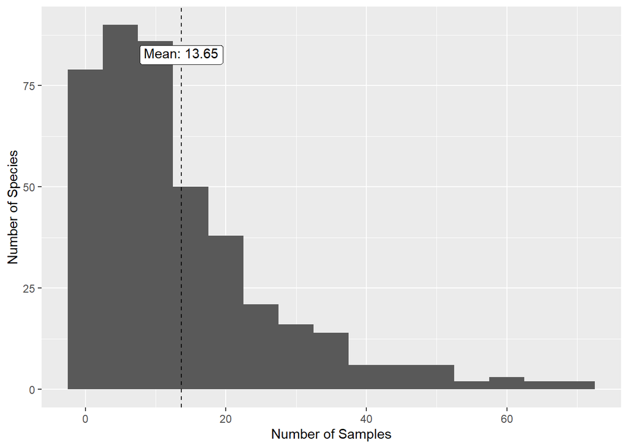

```r
species_nsamples = data.frame(modeling_data) %>%
                    count(species, sort=TRUE) %>%
                    rename(n_samples = n) %>%
                    filter(!is.na(species))

ggplot(species_nsamples, aes(n_samples)) +
       geom_histogram(binwidth = 5) +
       geom_vline(aes(xintercept=mean(n_samples)), linetype="dashed") +
       annotate(x=mean(species_nsamples$n_samples), y=+Inf, label=paste("Mean:",round(mean(species_nsamples$n_samples),2)), vjust=3, geom="label") +
       labs(x = "Number of Samples", y = "Number of Species")
```

```r
rm(species_nsamples)
```

## 5.3 ) Training and prediction with xgboost

Starting with the training of our xgboost model we decided to do sperate training for every model. Despite that xgboost is capable of Multi-Classificiation. Therefor we defined a function ‘train’ wich invokes out data filtering and xgboost specific data preperation to meet the requirements of xgboost. Espacially converting the modeling data into a ‘xgb.DMatrix’ object. Finally we define some general parameters we want to use, e.g. enable of gpu acceleration by knit paramters. Last but not least we save the model to the disk to preserve it for modeling.

```r
train <- function(
    data, # training data, required
    sp, # species name, required
    xgb_params = list("nrounds" = 1000), # xgboost params, see https://xgboost.readthedocs.io/en/latest/parameter.html
    save_model = TRUE
) {
# filter modeling data to current species, don't forget the absence points!
data <- modeling_data %>% filter(species == sp | is.na(species))
data <- dummy_columns(data, select_columns = "species",
                      ignore_na = TRUE,
                      remove_selected_columns = TRUE)

# make dummy_columns name persistent over all species
# replace NA values with 0
data <- data %>%
  rename(species_occurrence = starts_with("species_")) %>%
  mutate(species_occurrence = ifelse(is.na(species_occurrence), 0, species_occurrence)) %>%
  mutate(species_occurrence = factor(species_occurrence))

# xgboost need a specific data format
data <- xgb.DMatrix(
  data = as.matrix(data %>% select(-species_occurrence, -geometry)),
  label = as.matrix(data %>% select(species_occurrence))
)

# enable gpu acceleration only if wanted
if(params$gpu_acc) {
  xgb_params = c(xgb_params, predictor="gpu_predictor")
  xgb_params = c(xgb_params, tree_method="gpu_hist")
  xgb_params = c(xgb_params, sampling_method = "gradient_based")
}
#xgb_params = c(xgb_params, eval_metric="error") # Binary classification error rate. It is calculated as #(wrong cases)/#(all cases). For the predictions, the evaluation will regard the instances with prediction value larger than 0.5 as positive instances, and the others as negative instances.
xgb_params = c(xgb_params, objective = "binary:logistic") # logistic regression for binary classification, output probability

model <- xgboost(data = data,
                 verbose = 0,            # 0 (silent), 1 (warning), 2 (info), 3 (debug)
                 nrounds = xgb_params$nrounds,
                 params = xgb_params
                 )

message(paste("train_logloss:", mean(model[["evaluation_log"]][["train_logloss"]])))

if(save_model)
{
  xgb.save(model, paste("out/", sp, ".model", sep = ""))  # Max compatibility with future xgboost versions
  save(model, file = paste("out/", sp, ".rds", sep = "")) # Fully restorable r object
}

return(model)
}
```

Additional training paramters are defined here in a own data frame. Advantage of this are the comparability and useability of the different parameter sets. The Table show the default parameter, one set taken from Roozbeh Valavi et. al. And last the parameters we will user for training. Those have been tested and tuned manually.

```r
rm(xgboost_params)
xgboost_params <- data.frame("dataset" = character(),
                             "nrounds" = numeric(),
                             "eta" = numeric(),
                             "max_depth" = numeric(),
                             "subsample" = numeric(),
                             "gamma" = numeric(),
                             "alpha" = numeric(),
                             "lambda" = numeric(),
                             "colsample_bytree" = numeric(),
                             "min_child_weight" = numeric()
                             )

xgboost_params <- xgboost_params %>% add_row(dataset = "default", eta = 0.3, max_depth = 6, gamma = 0, alpha = 0, lambda = 1, subsample = 1, colsample_bytree = 1, min_child_weight = 1)

# Parameter taken from https://esajournals.onlinelibrary.wiley.com/doi/full/10.1002/ecm.1486
xgboost_params <- xgboost_params %>% add_row(dataset = "literature", nrounds = 1000, eta = 0.001, max_depth = 5, subsample = 0.75, gamma = 0, alpha = 0, lambda = 1, colsample_bytree = 0.8, min_child_weight = 1)

xgboost_params <- xgboost_params %>% add_row(dataset = "tuned 1", nrounds = 2000, eta = 0.01, max_depth = 5, subsample = 1, gamma = 0, alpha = 0, lambda = 1, colsample_bytree = 1, min_child_weight = 1)

xgboost_params <- xgboost_params %>% add_row(dataset = "tuned 2", nrounds = 5000, eta = 0.3, max_depth = 5, subsample = 1, gamma = 2, alpha = 0, lambda = 1, colsample_bytree = 1, min_child_weight = 1)

xgboost_params <- xgboost_params %>% add_row(dataset = "tuned 3", nrounds = 3000, eta = 0.15, max_depth = 7, subsample = 0.75, gamma = 1.5, alpha = 0, lambda = 0.5, colsample_bytree = 1, min_child_weight = 1)

print(xgboost_params)
```

```
##      dataset nrounds   eta max_depth subsample gamma alpha lambda
## 1    default      NA 0.300         6      1.00   0.0     0    1.0
## 2 literature    1000 0.001         5      0.75   0.0     0    1.0
## 3    tuned 1    2000 0.010         5      1.00   0.0     0    1.0
## 4    tuned 2    5000 0.300         5      1.00   2.0     0    1.0
## 5    tuned 3    3000 0.150         7      0.75   1.5     0    0.5
##   colsample_bytree min_child_weight
## 1              1.0                1
## 2              0.8                1
## 3              1.0                1
## 4              1.0                1
## 5              1.0                1
```

Next is to perpare data used to predic species occurrence in pakistan. Therefore we will use the raw raster data and predict of those with ‘terra::predict’ which allows us to pass on a ‘Spatraster’ object. XGBoost can’t handle Spatraster, so ‘terra:predict’ allows as to define a custom prediction function, which converts data into a matrix.

```r
# gen stack from rasters bioclim_pak and elevation_pak
elev_pak = resample(elevation_pak, bioclim_pak)
ext(elevation_pak) <- ext(bioclim_pak)
prediction_rstack = c(bioclim_pak, elev_pak)

# Remove values outside pakistan, because otherwise the model will make predictions outside the modeling area
prediction_rstack = terra::mask(prediction_rstack, border_pak)
```

```r
# We need to make a custom predict function for terra::predict() since xgboost didn't take a data.frame as input. See https://stackoverflow.com/questions/71947124/predict-xgboost-model-onto-raster-stack-yields-error
prediction_custom <- function(model, data, ...) {
  stats::predict(model, newdata=as.matrix(data), ...)
}

predict <- function(model, prediction_data, plots=FALSE)
{

  #model = xgb.load(paste("out/", sp, "/" ,sp, ".model", sep = ""))
  #model = readRDS(paste("out/", sp, "/" ,sp, ".bin", sep = ""))
  prediction = terra::predict(object=prediction_data,
                       model=model,
                       fun=prediction_custom
  )

  terra::writeRaster(prediction, paste("out/", sp, ".tif", sep = ""), overwrite=TRUE)
  return(prediction)
}
```

## 5.4 ) Example model for species “Aglais_caschmirensis”

Three different paramter sets used for Aglais_caschmirensis

```r
sp = "Aglais_caschmirensis"

print(xgboost_params[2,])


model <- train(modeling_data, sp, as.list(xgboost_params[2,]), save_model = FALSE)
```

```
## train_logloss: 0.420199630154574
```

```
## SpatRaster resampled to ncells = 500703
```

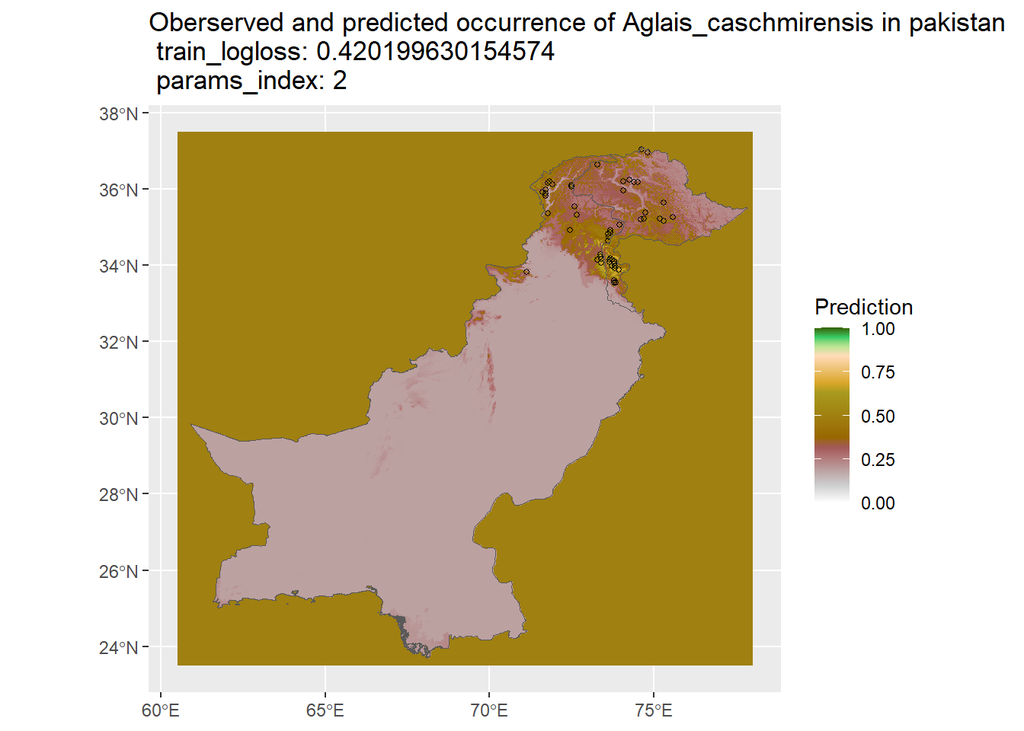

```r
prediction <- predict(model, prediction_rstack)
ggplot() +
  geom_spatraster(data = prediction) +
  scale_fill_hypso_c(direction = -1,
                     limits=c(0,1),
                     name = "Prediction") +
  geom_sf(data = modeling_data %>% filter(species == sp),
          size = 1,
          shape = 1 ) +
  geom_sf(data = sf::st_as_sf(border_pak),
          fill = NA, show.legend=FALSE) +
   ggtitle(paste("Oberserved and predicted occurrence of", sp, "in pakistan \n", paste("train_logloss:", mean(model[["evaluation_log"]][["train_logloss"]])), "\n params_index: 2"))
```

```r
rm(sp)
```

[output not shown]

```r
sp = "Aglais_caschmirensis"

print(xgboost_params[4,])

model <- train(modeling_data, sp, as.list(xgboost_params[4,]), save_model = FALSE)
```

```
## train_logloss: 0.0508811148403587
```

```
## SpatRaster resampled to ncells = 500703
```

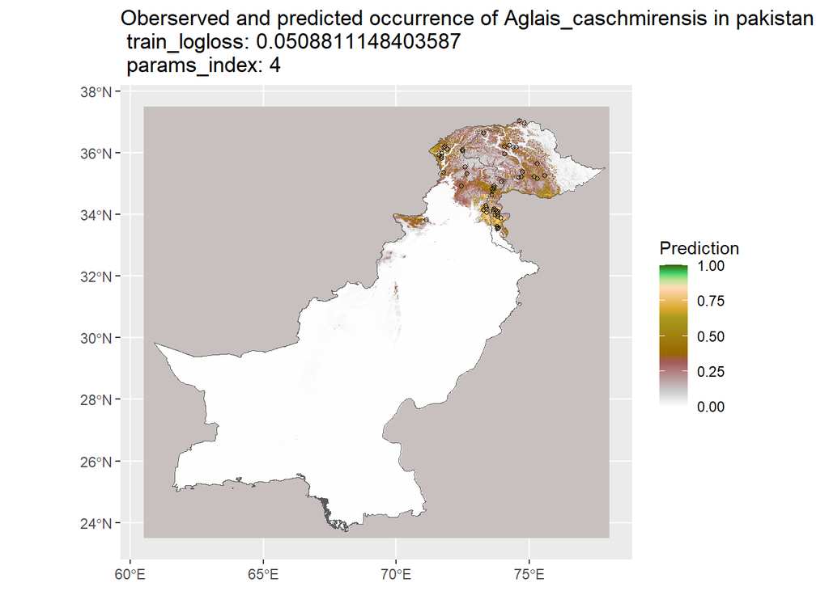

```r
prediction <- predict(model, prediction_rstack)
ggplot() +
  geom_spatraster(data = prediction) +
  scale_fill_hypso_c(direction = -1,
                     limits=c(0,1),
                     name = "Prediction") +
  geom_sf(data = modeling_data %>% filter(species == sp),
          size = 1,
          shape = 1 ) +
  geom_sf(data = sf::st_as_sf(border_pak),
          fill = NA, show.legend=FALSE) +
   ggtitle(paste("Oberserved and predicted occurrence of", sp, "in pakistan \n", paste("train_logloss:", mean(model[["evaluation_log"]][["train_logloss"]])), "\n params_index: 4"))
```

```r
rm(sp)
```

[output not shown]

```r
sp = "Aglais_caschmirensis"

print(xgboost_params[5,])

model <- train(modeling_data, sp, as.list(xgboost_params[5,]), save_model = FALSE)
```

```
## train_logloss: 0.0214214999609754
```

```
## SpatRaster resampled to ncells = 500703
```

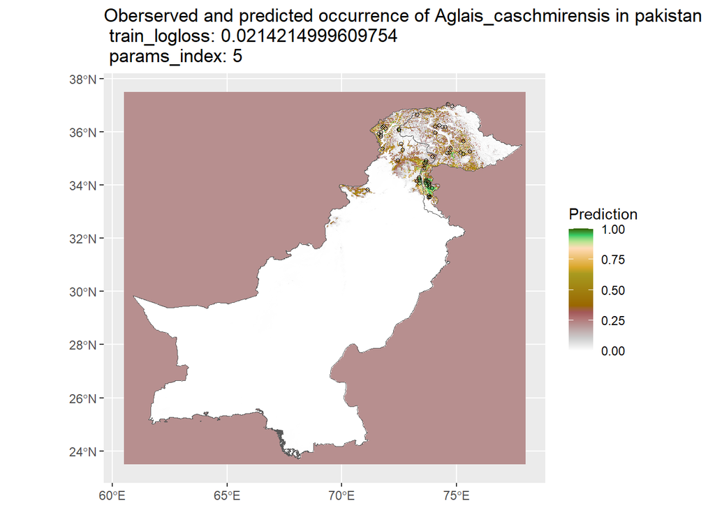

```r
prediction <- predict(model, prediction_rstack)
ggplot() +
  geom_spatraster(data = prediction) +
  scale_fill_hypso_c(direction = -1,
                     limits=c(0,1),
                     name = "Prediction") +
  geom_sf(data = modeling_data %>% filter(species == sp),
          size = 1,
          shape = 1 ) +
  geom_sf(data = sf::st_as_sf(border_pak),
          fill = NA, show.legend=FALSE) +
   ggtitle(paste("Oberserved and predicted occurrence of", sp, "in pakistan \n", paste("train_logloss:", mean(model[["evaluation_log"]][["train_logloss"]])), "\n params_index: 5"))
```

```r
rm(sp)
```

[output not shown]

```r
  if(plot) {
    #xgb_model[["evaluation_log"]]

    importance <- xgb.importance(model = model)
    #xgb.plot.importance(importance_matrix = importance)

    #xgb.ggplot.deepness(xgb_model)

    #xgb.plot.multi.trees(mode = xgb_model, features_keep = 3)

    #library("DiagrammeRsvg", "rsvg")


    #gr <- xgb.plot.multi.trees(model=xgb_model, features_keep = 5, render=FALSE)
    #DiagrammeR::export_graph(gr, 'tree.pdf', width=600, height=1500)

    xgb.ggplot.shap.summary(data = as.matrix(modeling_data %>% select(-species_occurrence, -geometry)), model = model )
    ggsave(paste(sp, "_shap.png", sep=""), path=paste("out/",sp, sep=""))
    rm(importance)
  }
```

## 5.5 ) Species Richness Map

```r
time_start <- proc.time()
i <- 0

species = (modeling_data %>% distinct(species) %>% filter(!is.na(species)))$species

# xgboost needs the output dir to exist before saving model
system("mk out")

for(sp in species)
{
  time_start_species <- proc.time()
  i <- i+1
  message(paste("[", i, "/", length(species), "] ", sp, ": ", sep = ""), appendLF=F)

  # training and prediction of the species model
  model <- train(modeling_data, sp, as.list(xgboost_params[5,]))
  prediction <- predict(model, prediction_rstack)


  ggplot() +
    geom_spatraster(data = prediction) +
    scale_fill_hypso_c(direction = -1,
                       limits=c(0,1),
                       name = "Prediction") +
    geom_sf(data = modeling_data %>% filter(species == sp),
            size = 1,
            shape = 1 ) +
    geom_sf(data = sf::st_as_sf(border_pak),
            fill = NA, show.legend=FALSE) +
    ggtitle(paste("Oberserved and predicted occurrence of", sp, "in pakistan \n", paste("train_logloss:", mean(model[["evaluation_log"]][["train_logloss"]]))))
  ggsave(paste(sp, ".png", sep=""), path="out")

  message(paste("Exceution took", proc.time() - time_start_species, "seconds"))
}
```

```
## [1/421] Acraea_issoria: train_logloss: 0.00664921361043314
## SpatRaster resampled to ncells = 500703
## [2/421] Acraea_violae: train_logloss: 0.0119692175653852
## SpatRaster resampled to ncells = 500703
## [3/421] Actinor_radians: train_logloss: 0.00871972616658507
## SpatRaster resampled to ncells = 500703
## [4/421] Acytolepis_puspa: train_logloss: 0.00656441265305648
## SpatRaster resampled to ncells = 500703
## [5/421] Aeromachus_stigmatus: train_logloss: 0.00663852743547008
## SpatRaster resampled to ncells = 500703
## [6/421] Aglais_caschmirensis: train_logloss: 0.0211064029808852
## SpatRaster resampled to ncells = 500703
## [7/421] Aglais_rizana: train_logloss: 0.0131684538836404
## SpatRaster resampled to ncells = 500703
## [8/421] Anaphaeis_aurota: train_logloss: 0.0300897856195072
## SpatRaster resampled to ncells = 500703
## [9/421] Apolria_nabellica: train_logloss: 0.00810993300860592
## SpatRaster resampled to ncells = 500703
## [10/421] Aporia_belucha: train_logloss: 0.0195745660737532
## SpatRaster resampled to ncells = 500703
## [11/421] Aporia_soracta: train_logloss: 0.0071801739418697
## SpatRaster resampled to ncells = 500703
## [12/421] Appias_albina: train_logloss: 0.00901366008048808
## SpatRaster resampled to ncells = 500703
## [13/421] Appias_libythea: train_logloss: 0.0111645782609531
## SpatRaster resampled to ncells = 500703
## [14/421] Argynnis_aglaja: train_logloss: 0.01607620936872
## SpatRaster resampled to ncells = 500703
## [15/421] Argynnis_childreni: train_logloss: 0.00958086930335749
## SpatRaster resampled to ncells = 500703
## [16/421] Argynnis_jainadeva: train_logloss: 0.0159044216295827
## SpatRaster resampled to ncells = 500703
## [17/421] Argynnis_kamala: train_logloss: 0.0119069546949637
## SpatRaster resampled to ncells = 500703
## [18/421] Argynnis_niobe: train_logloss: 0.00902238748999653
## SpatRaster resampled to ncells = 500703
## [19/421] Argynnis_pandora: train_logloss: 0.00746317263916446
## SpatRaster resampled to ncells = 500703
## [20/421] Argyreus_hyperbius: train_logloss: 0.0200453973630997
## SpatRaster resampled to ncells = 500703
```

[output cut: 787 more lines]

```
## SpatRaster resampled to ncells = 500703
## [415/421] Polyommatus_chrysopis: train_logloss: 0.00831061334790385
## SpatRaster resampled to ncells = 500703
## [416/421] Polyommatus_hunza: train_logloss: 0.00752112315777541
## SpatRaster resampled to ncells = 500703
## [417/421] Polyommatus_lehanus: train_logloss: 0.00811294425166799
## SpatRaster resampled to ncells = 500703
## [418/421] Polyommatus_pulchella: train_logloss: 0.00901884261466987
## SpatRaster resampled to ncells = 500703
## [419/421] Polyommatus_stoliczkana: train_logloss: 0.00786780008619682
## SpatRaster resampled to ncells = 500703
## [420/421] Pyrgus_alpinus: train_logloss: 0.0111230423690765
## SpatRaster resampled to ncells = 500703
## [421/421] Satyrus_alaicus: train_logloss: 0.00780765979761284
## SpatRaster resampled to ncells = 500703
```

```r
message(paste("Total Exceution took", proc.time() - time_start, "seconds"))
```

```
## Total Exceution took 110361.03 secondsTotal Exceution took 7177.2 secondsTotal Exceution took 13850.42 secondsTotal Exceution took NA secondsTotal Exceution took NA seconds
```

[output not shown]

[output cut: 1208 more lines]

[output not shown]